# Part IV – Cluster Themes with Agglomerative Hierarchical Clustering

Rees Morrison

2022-01-29

Part I of this working series introduced Themes, and Part II introduced the metrics for those Themes. Part III started the analysis of centrality and complexity by an unsupervised clustering algorithm, k-means clustering. It requires the analyst to specify the number of clusters, and figuring out the optimal number of clusters can often be hard. Part III side-stepped that challenge because the k-means algorithm was asked to find 12 clusters, ideally therefore identifying the closest, most-similar Themes. In this post we introduce a second algorithm for the same task. **Agglomerative hierarchical clustering** is an alternative unsupervised approach; it builds a hierarchy of closest Themes and doesn’t require a pre-specified number of clusters. That orderly construction of clustering helps identify most-similar Themes, referred to as “closest pairs.”

The algorithm starts by putting each Theme in its own unit. It then identifies the closest other Theme to a unit by the Euclidean distance between them in the hyperspace of metrics dimensions (each Theme is a vector in that 20-dimensional space). At first, a single Theme is clumped with another single Theme, each clumping thereby creating a two-Theme unit. Step-by-step the algorithm agglomerates each remaining Theme (or unit) to its closest Theme or unit. The algorithm keeps combining Themes with their closest Themes or units (based on the chosen **link method**, e.g., average linkage); if an already-agglomerated cluster is closest, it clusters the nearest Theme with that unit. Eventually, all the Themes rest in a single cluster.

Once the clustering ends, the results are usually visualized by a **dendrogram**. On the dendrogram, you can tell that two Themes are most similar because the height of the link that joins them together is short. That height on the y-axis is the value of the distance metric between the two Themes. so, Alcohol and Silence (second and third from the left on the x axis) are combined to form the first unit. The next-to-last agglomeration puts Sports with Work and Time (far right).

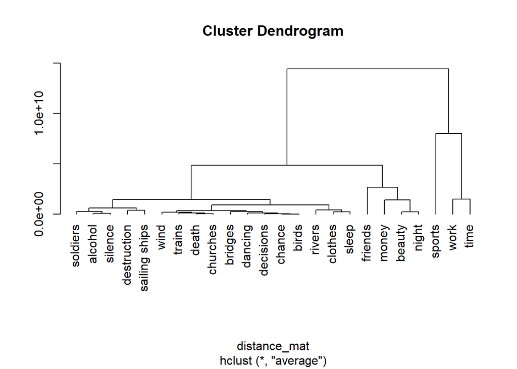

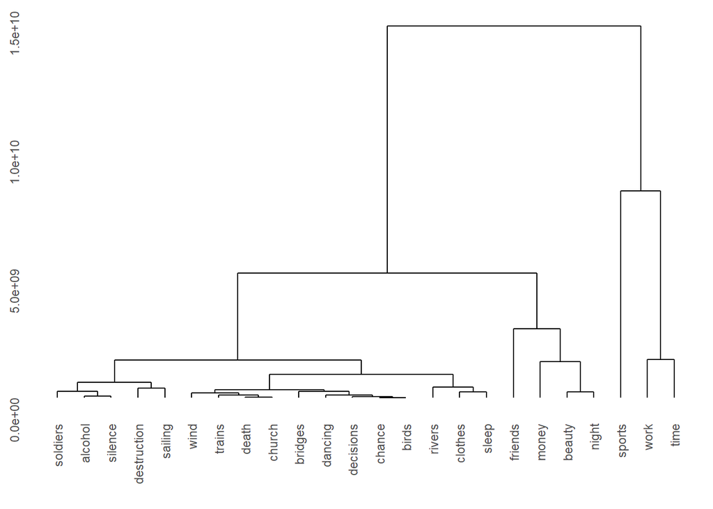

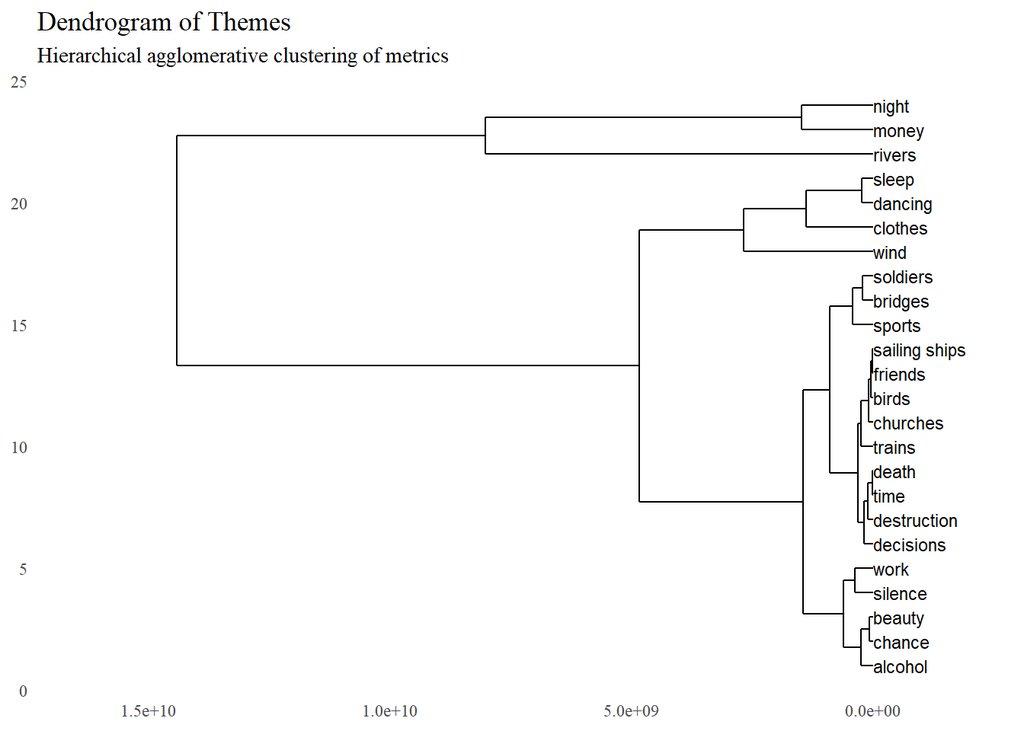